# Bootstrap Examples

Anna Frowein

October 27, 2016

# Creation of Population

The original sample is from my MapMyRun account. I pull my last 12 runs that were tracked and recorded my pace, minutes per mile, in vector P. This sample moving forward will be considered the the population. I then ran the mean, standard deviation and charted the data.

```r
P<-c(13.39, 10.3, 9.31, 10.16, 11.42, 10.56, 11.53, 10.17, 11.04, 10.42, 10.49, 10.57)
mean(P) #mean of the original sample, now being used as the population
```

```
## [1] 10.78
```

```r
sd(P) #Standard Deviation of the sample now being used as the population
```

```
## [1] 1.013805
```

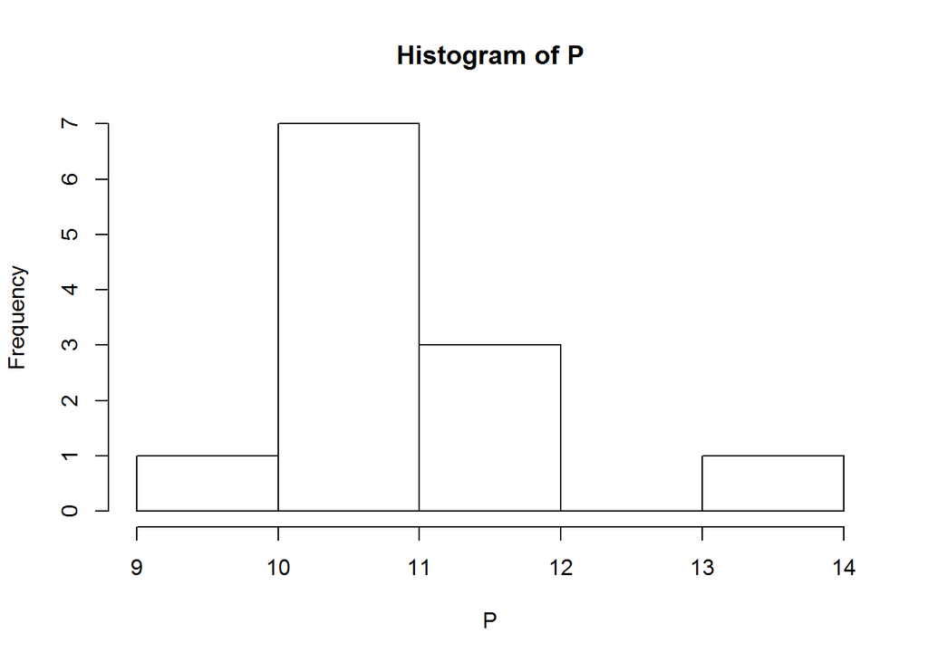

```r
#Histogram and QQPlot of the Population
hist(P)
```

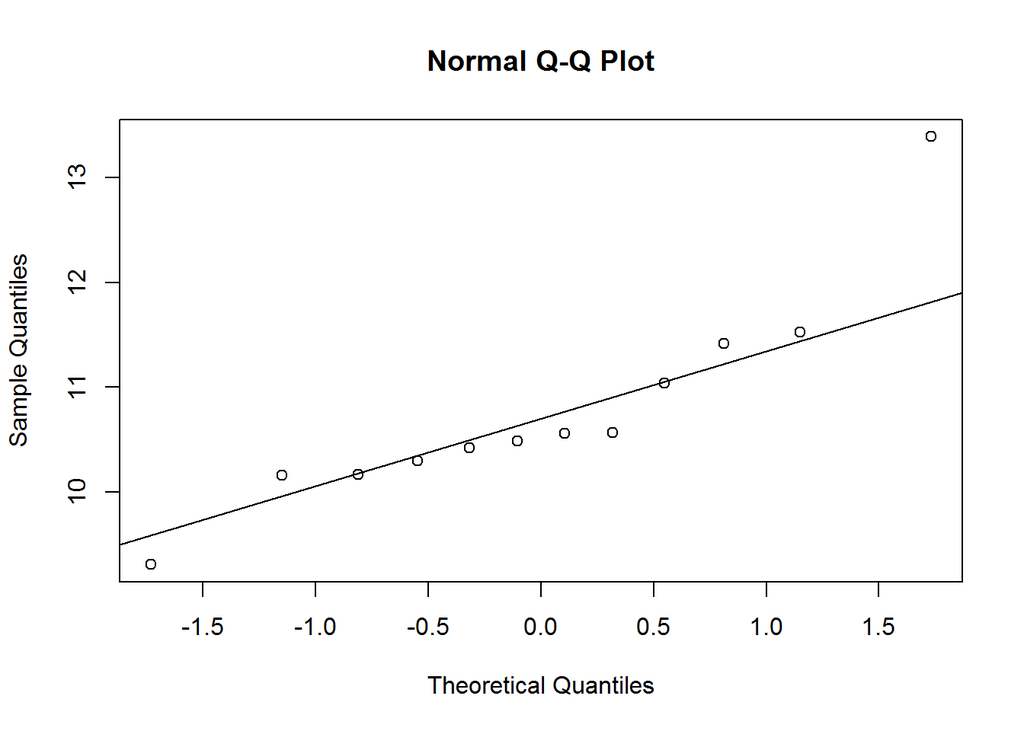

```r
qqnorm(P)
qqline(P)
```

# Central Limit Therorem

The Central Limit Theorem states that if take sample means from a given population the means will be normally distributed, using the bootstrap concept we can demonstrate the Central Limit Theorem.

# Bootstrap Example 1

## Means of 12 Samples from Population

Using a sampling method in R that will randomly select 12 variables from the P vector, with each selection of a sample the sample is put back into the population so that there is a chance it could be picked again. I created a vector that would create 1000 sample means of the 12 samples.

```r
#Vector for setting up size of the bootstrap example vectors.
s<-1000
#Bootstrap 1 example of 1000 means using 12 samples from the original population P vector
Bootstrap1<-numeric(s)
for (i in 1:s) {
  bootsample<-sample(P,size=length(P),replace=T)
  Bootstrap1[i]<-mean(bootsample)}
#Mean and Standard Deviation of Bootstrap 1 example with 12 sample size
mean(Bootstrap1)
```

```
## [1] 10.79198
```

```r
sd(Bootstrap1)
```

```
## [1] 0.29001
```

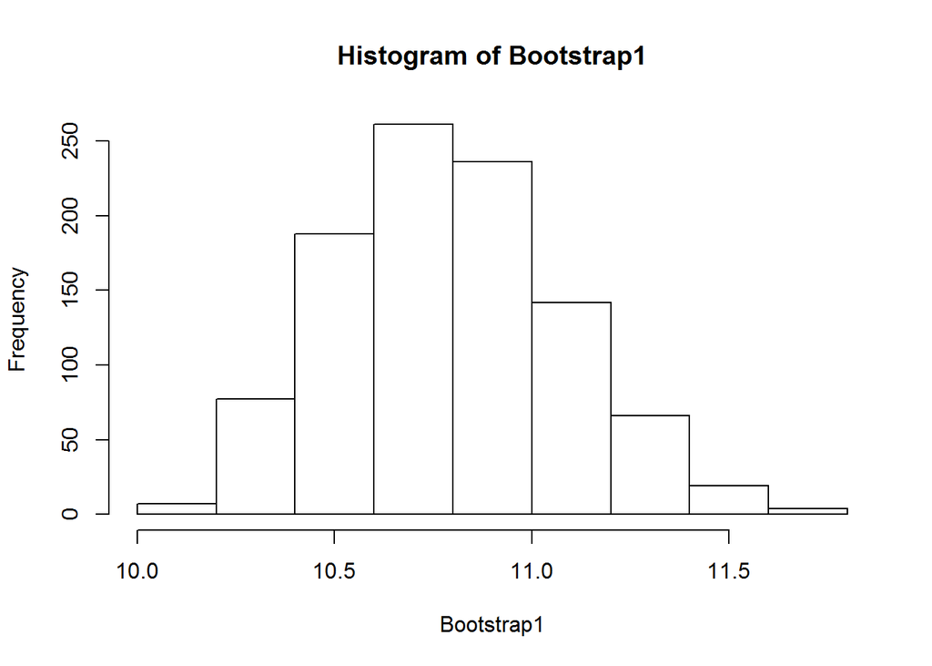

```r
#Histogram and QQPlot of the Bootstrap 1 example with 12 sample size
hist(Bootstrap1)
```

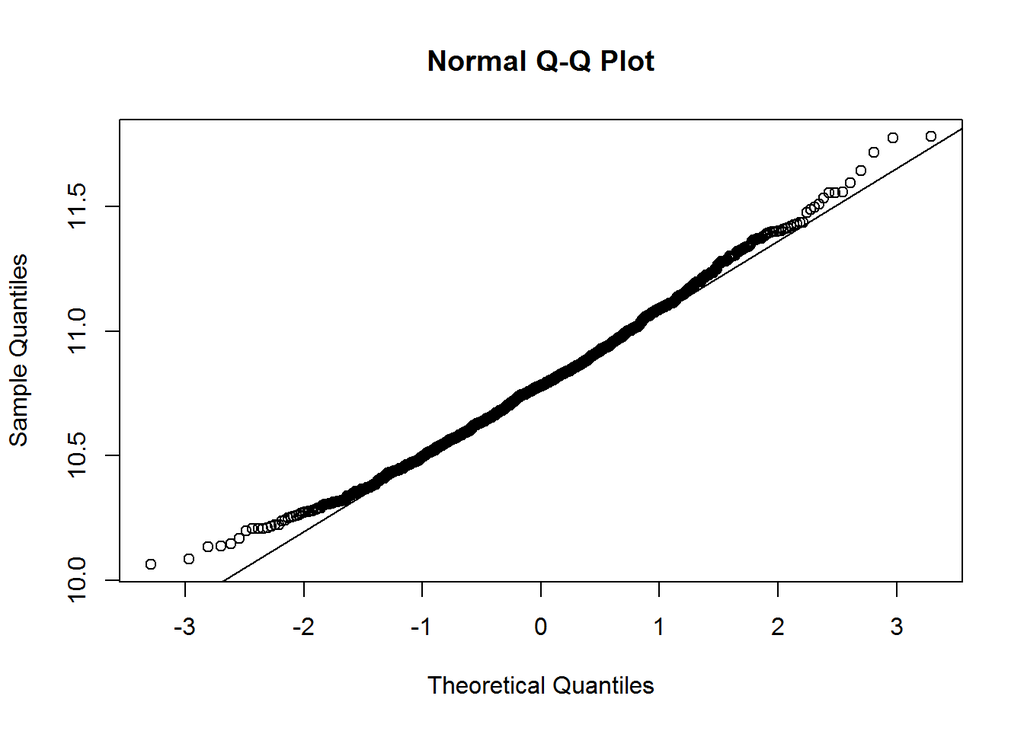

```r
qqnorm(Bootstrap1)
qqline(Bootstrap1)
```

# Bootstrap Example 2

## Means of 6 Samples from Population

Using the same methodology of Example 1, just change the sample size from 12 to 6 for Example 2. The Bootstrap example contains 1000 sample means as before.

```r
#Bootstrap 2 example of means using 6 samples from the original population P vector
Bootstrap2<-numeric(s)
for (i in 1:s) {
  bootsample<-sample(P,size=6,replace=T)
  Bootstrap2[i]<-mean(bootsample)}
#Mean and Standard Deviation of Bootstrap 1 example with 6 sample size
mean(Bootstrap2)
```

```
## [1] 10.7783
```

```r
sd(Bootstrap2)
```

```
## [1] 0.396037
```

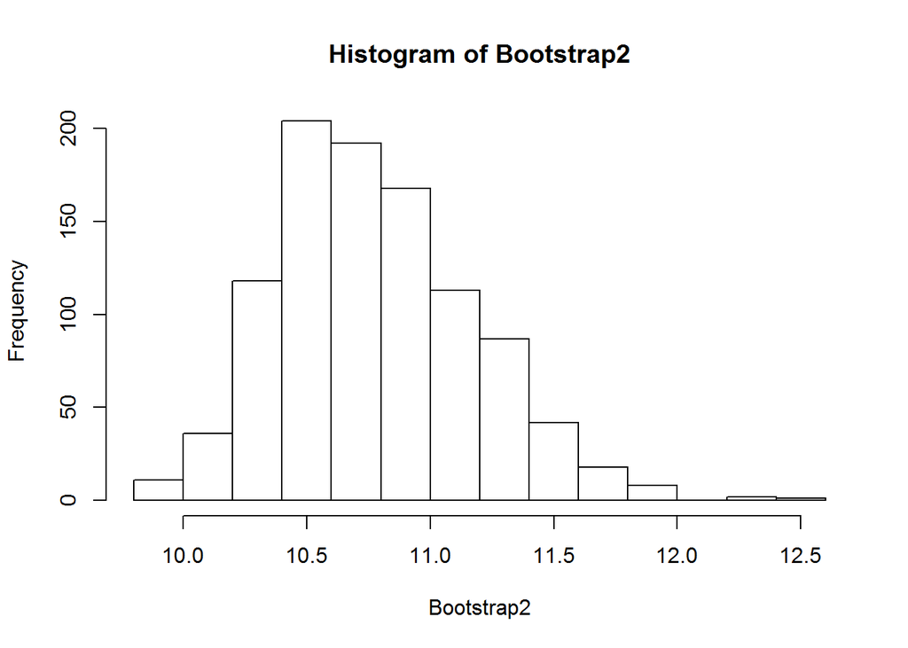

```r
#Histogram and QQPlot of the Bootstrap 1 example with 6 sample size
hist(Bootstrap2)
```

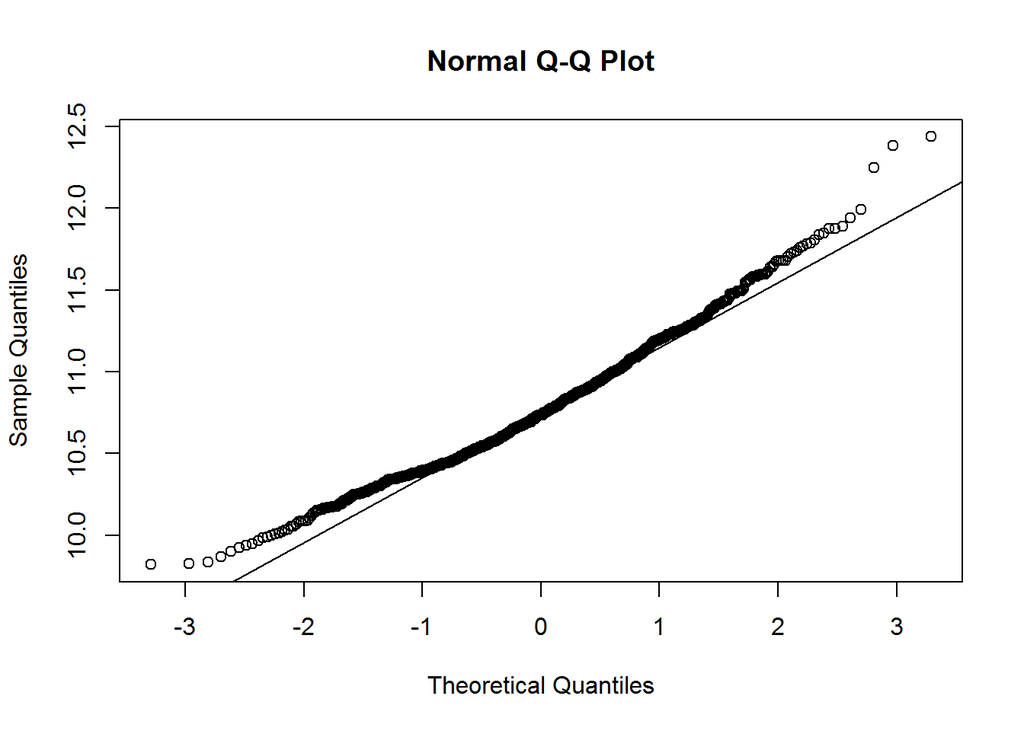

```r
qqnorm(Bootstrap2)
qqline(Bootstrap2)
```

# Conclusion

The larger sample size of 12 had more normality than that sample size of 6. However, with both examples we do see that the sampled means do show more normality than the original data set.